## 空間分析 作業六

#### 地理四 B03208011 杜承軒

> ＊初步環境建置與讀取檔案

> ```r
> library(sp);library(rgdal);library (splancs);library(GISTools);library(ggplot2)
> setwd("C:/Users/user/Desktop/SA")
> source("ST_functions.R")
> ```

> > 問題一、建立自訂函數  
> > Q1-1.建立距離與時間矩陣

> ```r
> Dist_Matrix=function(X,Y){
>  n=length(X);M=matrix(0,n,n)
>  for(i in seq(1,n-1)){
>    for(j in seq(i+1,n)){
>      M[i,j]=sqrt((X[i]-X[j])^2+(Y[i]-Y[j])^2)
>    }}
>  return(M)
> }
>
> Time_Matrix=function(t){
>  n=length(t);M=matrix(0,n,n)
>  for(i in seq(1,n-1)){
>    for(j in seq(i+1,n)){
>      M[i,j]=abs(t[i]-t[j])
>    }}
>  return(M)
> }
> ```

> > Q1-2.建立時空關連圖

> ```r
> sptplot=function(X,Y,t){
>  n=length(t);  dismat=Dist_Matrix(X,Y);  timmat=Time_Matrix(t)
>  plot(0,0,"n",xlim=c(0,max(timmat)),ylim=c(0,max(dismat)),
>       xlab="Time-Distance",ylab="Space-Distance",main="Space-Time Association")
>  for(i in seq(1,n-1)){
>    for(j in seq(i+1,n)){
>      points(timmat[i,j],dismat[i,j],col="red",pch=20)
>    }}
>  abline(h=sum(dismat)*2/(n-1)^2,col="blue",lwd=2) #以平均距離來劃分
>  abline(v=sum(timmat)*2/(n-1)^2,col="blue",lwd=2) #以平均時間間隔來劃分
> }
> ```

> > Q1-3.建立 Jacquez‘s k-NN曲線，含隨機區間

> ```r
> Jacquez.plot=function(X,Y,t){
>  res.T=data.frame();mon.T=data.frame()
>  for(k in 1:10){
>    out=Jacquez.test(X,Y,t,k,99)
>    res.T=rbind(res.T,data.frame(k=factor(k),t=out$Jacquez.T))
>    mon.T=rbind(mon.T,data.frame(k=factor(k),t=out$Freq))
>  }
>  ggplot()+geom_boxplot(data=mon.T,aes(x=k, y=t,col=k),fill="#AAAAAA",size=.8)+
>    geom_point(data=res.T,aes(x=k, y=t),col="red",size=3)+
>    geom_line(data=res.T,aes(x=c(1:10), y=t),col="red")+
>    labs(title="Jacquez's k-Nearest Neighbor Plot",x="k-nearest neighbor",y="Jacquez T")+
>    guides(col=FALSE)+
>    theme_light()+theme(plot.title = element_text(size=16,hjust = 0.5))
> }
> ```

> > 問題二、利用台北市某疾病的疫情資料進行時空風險評估

> ```r
> #匯入資料
> pts=readOGR(dsn = "ST_Data", layer = "point_tpe", encoding="big5",verbose = F)
> pdata=pts@data
> pd.x=pdata$X
> pd.y=pdata$Y
> pd.t=pdata$WEEK
> ```

> > Q2-1.使用Q1的函數進行時空分析 2-1-1. 距離與時間矩陣

> ```r
> pd.dis=Dist_Matrix(pd.x,pd.y)
> pd.tim=Time_Matrix(pd.t)
> pd.tim[1:10,1:10]
> ```

> ```
> ##       [,1] [,2] [,3] [,4] [,5] [,6] [,7] [,8] [,9] [,10]
> ##  [1,]    0   13    6    6    8    5    3    2   12     0
> ##  [2,]    0    0   19   19    5   18   10   15    1    13
> ##  [3,]    0    0    0    0   14    1    9    4   18     6
> ##  [4,]    0    0    0    0   14    1    9    4   18     6
> ##  [5,]    0    0    0    0    0   13    5   10    4     8
> ##  [6,]    0    0    0    0    0    0    8    3   17     5
> ##  [7,]    0    0    0    0    0    0    0    5    9     3
> ##  [8,]    0    0    0    0    0    0    0    0   14     2
> ##  [9,]    0    0    0    0    0    0    0    0    0    12
> ## [10,]    0    0    0    0    0    0    0    0    0     0
> ```

> ```r
> pd.dis[1:7,1:7]
> ```

> ```
> ##      [,1]     [,2]     [,3]     [,4]     [,5]      [,6]      [,7]
> ## [1,]    0 4062.697 9329.303 9329.303 2914.570 9613.9633 9489.2173
> ## [2,]    0    0.000 5339.513 5339.513 3584.772 5610.8525 5441.1224
> ## [3,]    0    0.000    0.000    0.000 8635.163  307.8246  758.1669
> ## [4,]    0    0.000    0.000    0.000 8635.163  307.8246  758.1669
> ## [5,]    0    0.000    0.000    0.000    0.000 8870.2181 8559.5073
> ## [6,]    0    0.000    0.000    0.000    0.000    0.0000  646.4093
> ## [7,]    0    0.000    0.000    0.000    0.000    0.0000    0.0000
> ```

> > 2-1-2. 時空關連圖

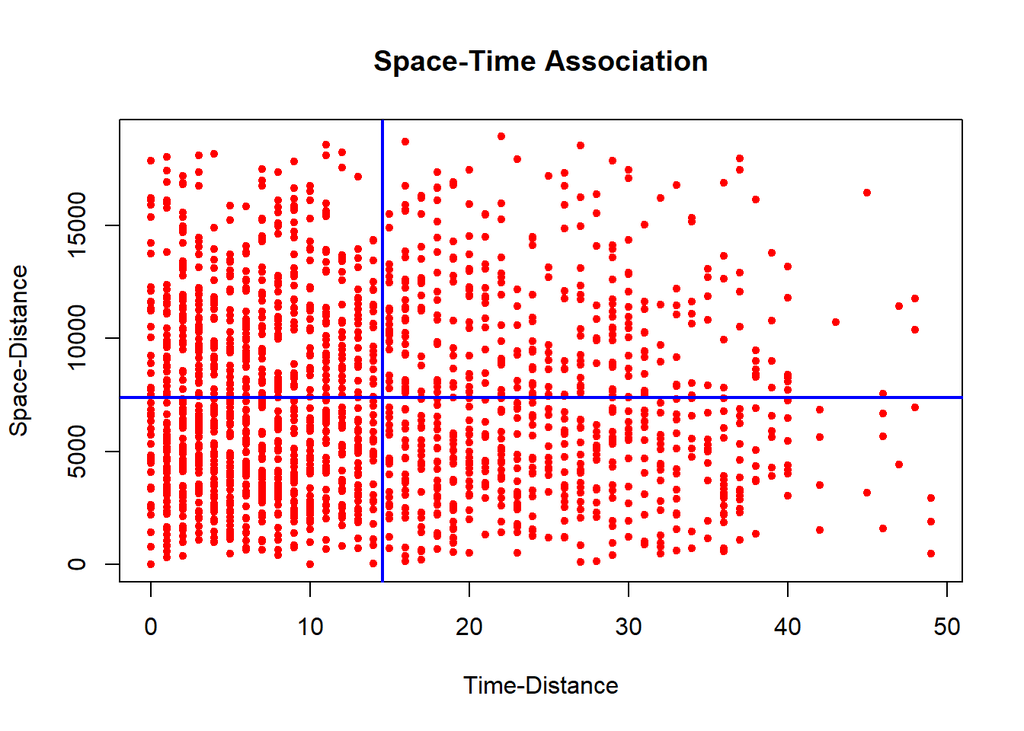

> ```r
> sptplot(pd.x,pd.y,pd.t)
> ```

> 藍線為平均距離與時間間隔。從關聯圖觀察時空資料分散，看似沒有時空相關的趨勢。

> > 2-1-3. Jacquez’s k-NN曲線

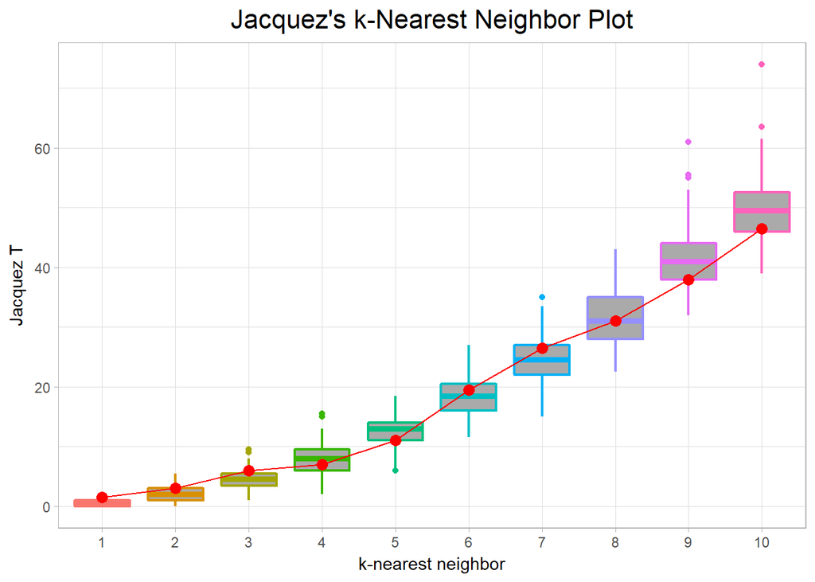

> ```r
> Jacquez.plot(pd.x,pd.y,pd.t)
> ```

> 紅點為計算出來的觀測值，箱型圖為模擬99次的結果。除了k=1時不明顯，其餘紅點都落在盒狀圖中，以Jacquez’s方法來說並無顯著時空相關。

> > Q2-2.其他時空分析

> > 2-2-1. Knox Test

> ```r
> KT=KnoxM.test(pd.x,pd.y,pd.t,2000,10,99)
> paste("Knox.T 統計值為：",KT$Knox.T,"；　模擬後的p-value為：",KT$Simulated.p.value)
> ```

> ```
> ## [1] "Knox.T 統計值為： 65 ；　模擬後的p-value為： 0.86"
> ```

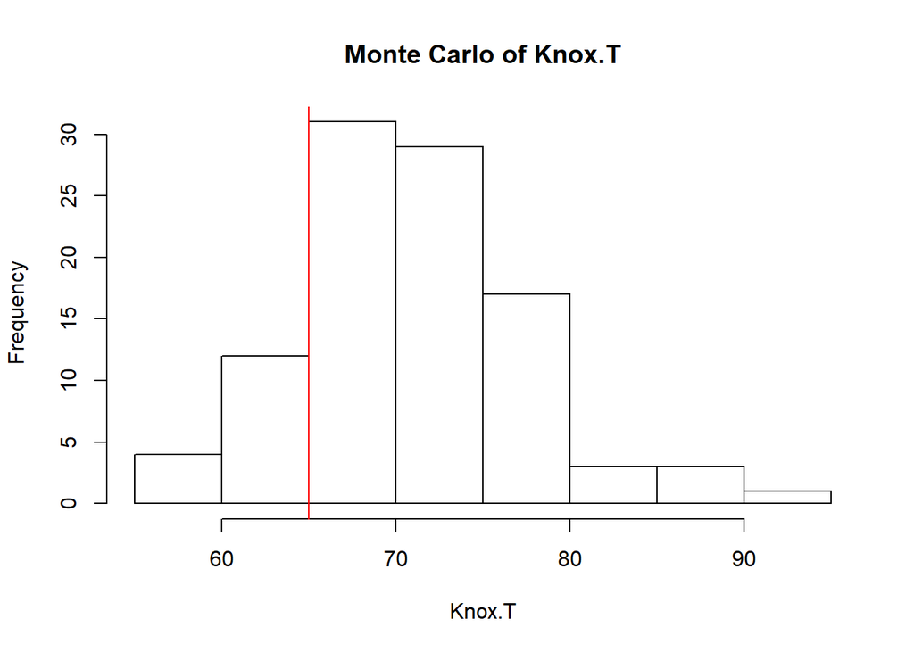

> ```r
> hist(KT$Freq, freq=T,main="Monte Carlo of Knox.T",xlab="Knox.T")
> abline(v=KT$Knox.T, col="red")
> ```

> 不顯著，在Knox Test中方法來說並無顯著時空群聚。

> > 2-2-2. Mantel Test

> ```r
> MT=Mantel.test(pd.x,pd.y,pd.t,0.1,0.1,99)
> paste("Mantel.T 統計值為：",MT$Mantel.T,"；　模擬後的p-value為：",MT$Simulated.p.value)
> ```

> ```
> ## [1] "Mantel.T 統計值為： 102.060167431139 ；　模擬後的p-value為： 0.01"
> ```

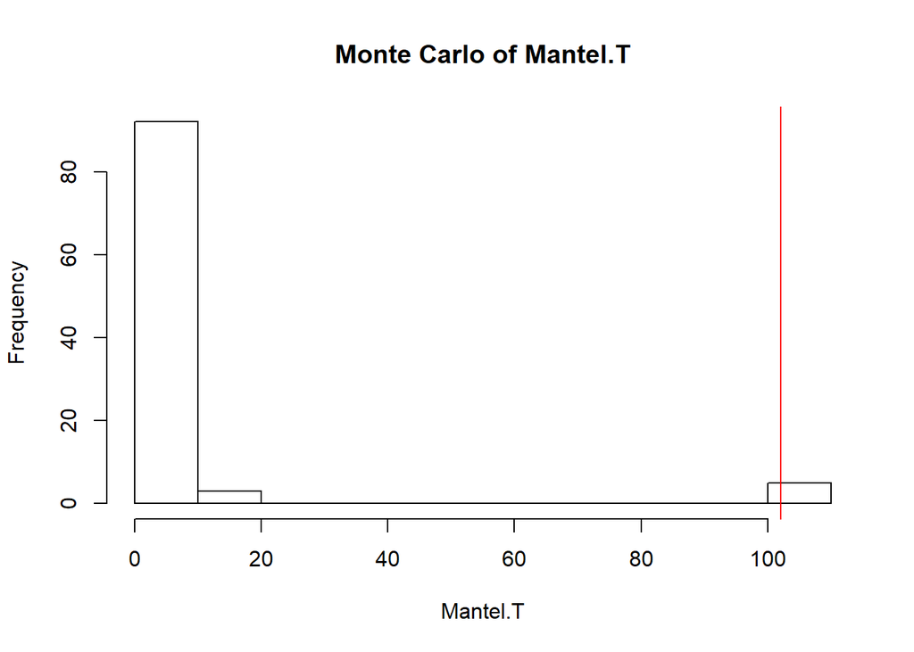

> ```r
> hist(MT$Freq, freq=T,main="Monte Carlo of Mantel.T",xlab="Mantel.T")
> abline(v=MT$Mantel.T, col="red")
> ```

> 顯著，在Mantel Test中方法來說，有時空群聚的現象。

> > 2-2-3. Jacquez Test (k=1時)

> ```r
> JT=Jacquez.test(pd.x,pd.y,pd.t,1,99)
> paste("Jacquez.T 統計值為：",JT$Jacquez.T,"；　模擬後的p-value為：",JT$Simulated.p.value)
> ```

> ```
> ## [1] "Jacquez.T 統計值為： 1.5 ；　模擬後的p-value為： 0.09"
> ```

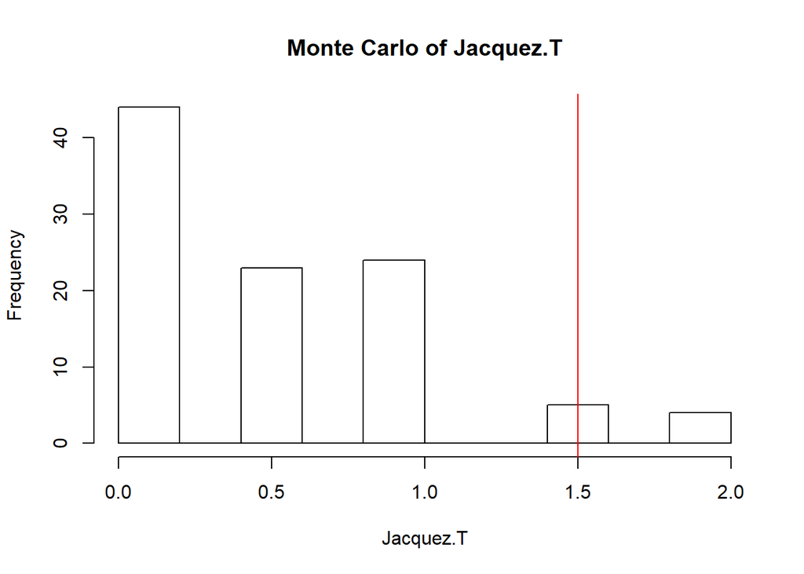

> ```r
> hist(JT$Freq, freq=T,main="Monte Carlo of Jacquez.T",xlab="Jacquez.T")
> abline(v=JT$Jacquez.T, col="red")
> ```

> 不顯著，在Jacquez Test中方法來說並無顯著時空群聚。

> > 2-2-4. Space-time K function

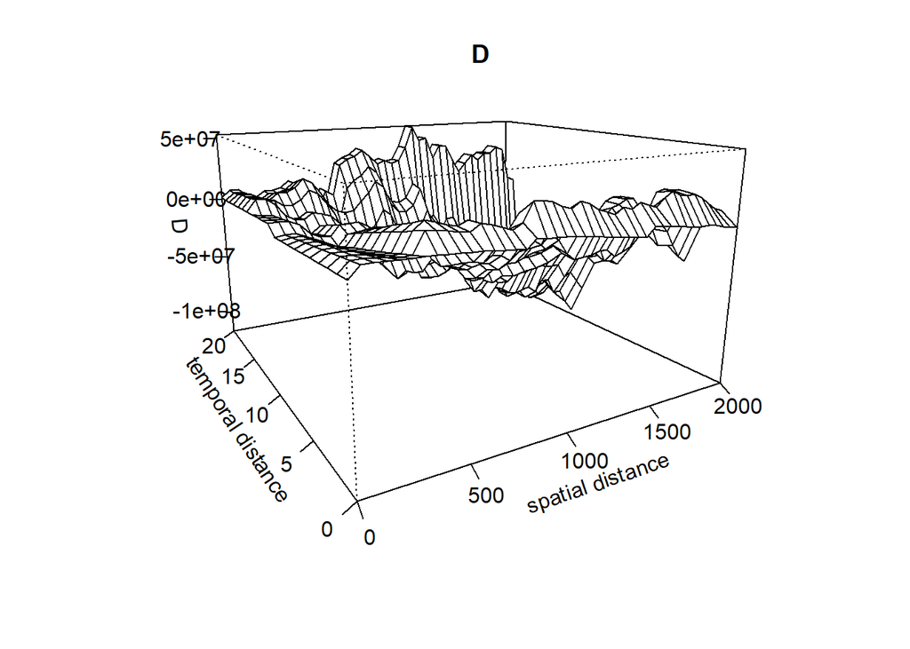

> ```r
> #邊界資料
> bondary=read.table("Data/tpe_sqr_bnd.csv", header=TRUE, sep=",")
> BDP=as.points(bondary[,2], bondary[,3])
> pd.pt=as.points(pd.x,pd.y)
>
> #畫出D圖與D0圖
> Kst=stkhat(pd.pt, pd.t, BDP, c(0,50),seq(0,2000,50),seq(0,20,1))
> Ks=matrix(Kst$ks)
> Kt=matrix(Kst$kt)
> KsKt=Ks%*% t(Kt)
>
> Dst=Kst$kst - KsKt
> persp(Kst$s,Kst$t,Dst,theta=-30, phi =15, expand = .6, xlab="spatial distance", ylab="temporal distance", zlab="D", ticktype ="detailed" ,main="D")
> ```

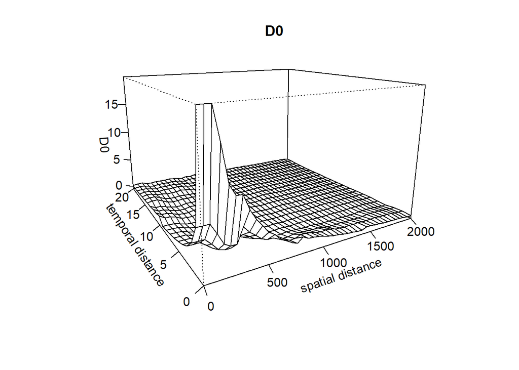

> ```r
> D0st=Dst/KsKt
> persp(Kst$s,Kst$t,D0st,theta=-30,phi = 15, expand = .6, xlab="spatial distance", ylab="temporal distance", zlab="D0", ticktype ="detailed",main="D0" )
> ```

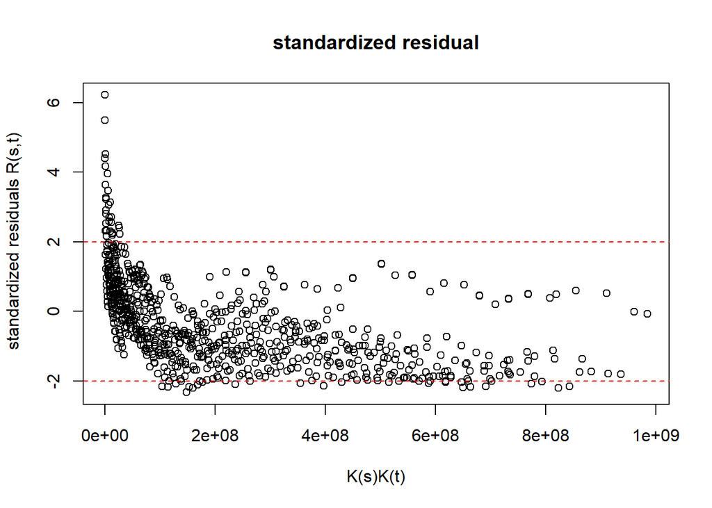

> ```r
> #畫出標準化後的殘差
> se=stsecal(pd.pt, pd.t, BDP, c(0,50),seq(0,2000,50),seq(0,20,1))
> res=Dst/ se
> plot(KsKt,res, xlab="K(s)K(t)", ylab=" standardized residuals R(s,t)",main="standardized residual")
> abline(h=c(-2,2), lty=2,col="red")
> ```

> 觀察D0的圖，能看出在距離在500公尺以內，時間間隔5單位以下，時空群聚的現象越明顯。隨時空距離上升，群聚就不明顯了。配合殘差的圖，可以看出只有在兩者乘積很小時才有顯著的現象。